# Moran’s Eigenvector Maps and related methods for the spatial multiscale analysis of ecological data

Stéphane Dray

2026-10-12

The package `adespatial` contains functions for the multiscale analysis of spatial multivariate data. It implements some new functions and reimplements existing functions that were available in packages of the sedaR project hosted on R-Forge (`spacemakeR`, `packfor`, `AEM`, etc.). It can be seen as a bridge between packages dealing with multivariate data (e.g., `ade4`, Dray and Dufour (2007)) and packages that deals with spatial data (`sp`, `spdep`). In `adespatial`, many methods consider the spatial information as a spatial weighting matrix (SWM), object of class `listw` provided by the `spdep` package (Figure 1). The SWM is defined as the Hadamard product (element-wise product) of a connectivity matrix by a weighting matrix. The binary connectivity matrix (spatial neighborhood, object of class `nb`) defines the pairs of connected and unconnected samples, while the weighting matrix allows weighting the connections, for instance to define that the strength of the connection between two samples decreases with the geographic distance.

Once SWM is defined, it can be used to build Moran’s Eigenvector Maps (MEM, Dray et al. (2006)) that are orthogonal vectors maximizing the spatial autocorrelation (measured by Moran’s coefficient). These spatial predictors can be used in multivariate statistical methods to provide spatially-explicit multiscale tools (Dray et al. 2012). This document provides a description of the main functionalities of the package.

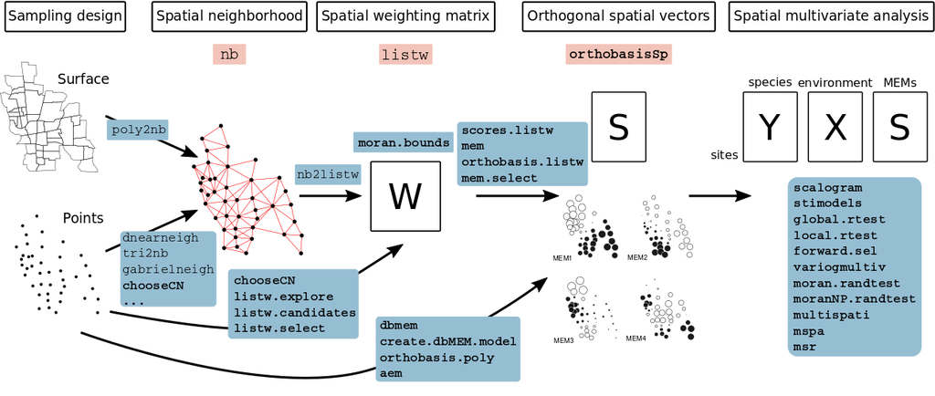

Figure 1: Schematic representation of the functioning of the `adespatial` package. Classes are represented in pink frames and functions in blue frames. Classes and functions provided by `adespatial` are in bold.

To run the different analysis described, several packages are required and are loaded:

```r
library(ade4)
library(adespatial)
```

```r
library(adegraphics)
library(spdep)
library(sp)
```

# 1 The Mafragh data set

The Mafragh data set is used to illustrate several methods. It is available in the `ade4` package and stored as a `list`:

```r
data("mafragh")
class(mafragh)
```

```
## [1] "list"
```

```r
names(mafragh)
```

```
##  [1] "xy"              "flo"             "env"             "partition"
##  [5] "area"            "tre"             "traits"          "nb"
##  [9] "Spatial"         "spenames"        "Spatial.contour"
```

```r
dim(mafragh$flo)
```

```
## [1] 97 56
```

The `data.frame` `mafragh$flo` is a floristic table that contains the abundance of 56 plant species in 97 sites in Algeria. Names of species are listed in `mafragh$spenames`. The geographic coordinates of the sites are given in `mafragh$xy`.

```r
str(mafragh$env)
```

```
## 'data.frame':    97 obs. of  11 variables:
##  $ Clay        : num  0.73 0.75 0.74 0.23 0.73 0.72 0.52 0.42 0.74 0.53 ...
##  $ Silt        : num  0.24 0.24 0.24 0.26 0.24 0.22 0.46 0.49 0.24 0.44 ...
##  $ Sand        : num  0.03 0.02 0.02 0.49 0.03 0.03 0.02 0.08 0.02 0.04 ...
##  $ K2O         : num  1.3 0.8 1.7 0.3 1.3 1.7 0.8 1.4 1.7 1.4 ...
##  $ Mg++        : num  9.2 10.7 8.6 2 9.2 6 6 19.6 8.6 17 ...
##  $ Na+/100g    : num  4.2 10.4 10.8 1.2 4.2 10.7 18.4 2.5 10.8 11.7 ...
##  $ K+          : num  1.2 1.4 1.9 0.3 1.2 1.3 2.2 1.3 1.9 0.5 ...
##  $ Conductivity: num  7.9 11.5 10.4 0.6 7.9 14.5 15.2 2.9 10.4 16.9 ...
##  $ Retention   : num  41.8 42.4 41.4 22.3 41.8 42.7 37.4 35.4 41.4 38 ...
##  $ Na+/l       : num  48.7 66 24 2.2 48.7 ...
##  $ Elevation   : num  6 2 2 6 6 4 4 3 3 6 ...
```

The `data.frame` `mafragh$env` contains 11 quantitative environmental variables. A map of the study area is also available (`mafragh$Spatial.contour`) that can be used as a background to display the sampling design:

[figure not shown]

```r
mxy <- as.matrix(mafragh$xy)
rownames(mxy) <- NULL
s.label(mxy, ppoint.pch = 15, ppoint.col = "darkseagreen4", Sp = mafragh$Spatial.contour)
```

A more detailed description of the data set is available at https://pbil.univ-lyon1.fr/R/pdf/pps053.pdf (in French).

The functionalities of the `adegraphics` package (Siberchicot et al. 2017) can be used to design simple thematic maps to represent data. For instance, it is possible to represent the spatial distribution of two species using the `s.Spatial` function applied on Voronoi polygons contained in `mafragh$Spatial`:

```r
mafragh$spenames[c(1, 11), ]
```

```
##                   scientific code
## Sp1         Arisarum vulgare Arvu
## Sp11 Bolboschoenus maritimus Boma
```

[figure not shown]

```r
fpalette <- colorRampPalette(c("white", "darkseagreen2", "darkseagreen3", "palegreen4"))
sp.flo <- SpatialPolygonsDataFrame(Sr = mafragh$Spatial, data = mafragh$flo, match.ID = FALSE)
s.Spatial(sp.flo[,c(1, 11)], col = fpalette(3), nclass = 3)
```

# 2 Building spatial neighborhood

Spatial neighborhoods are managed in `spdep` as objects of class `nb`. It corresponds to the notion of connectivity matrices discussed in Dray et al. (2006) and can be represented by an unweighted graph. Various functions allow to create `nb` objects from geographic coordinates of sites. We present different alternatives according to the design of the sampling scheme.

## 2.1 Surface data

The function `poly2nb` allows to define neighborhood when the sampling sites are polygons and not points (two regions are neighbors if they share a common boundary). The resulting object can be plotted on a geographical map using the `s.Spatial` function of the `adegraphics` package (Siberchicot et al. 2017).

```r
data(mafragh)
class(mafragh$Spatial)
```

```
## [1] "SpatialPolygons"
## attr(,"package")
## [1] "sp"
```

[figure not shown]

```r
nb.maf <- poly2nb(mafragh$Spatial)
s.Spatial(mafragh$Spatial, nb = nb.maf, plabel.cex = 0, pnb.edge.col = 'red')
```

## 2.2 Regular grid and transect

If the sampling scheme is based on regular sampling (e.g., grid of 8 rows and 10 columns), spatial coordinates can be easily generated:

[figure not shown]

```r
xygrid <- expand.grid(x = 1:10, y = 1:8)
s.label(xygrid, plabel.cex = 0)
```

For a regular grid, spatial neighborhood can be created with the function `cell2nb`. Two types of neighborhood can be defined. The `queen` specification considered horizontal, vertical and diagonal edges whereas the `rook` specification considered only horizontal and vertical edges:

[figure not shown]

```r
nb2.q <- cell2nb(8, 10, type = "queen")
nb2.r <- cell2nb(8, 10, type = "rook")
s.label(xygrid, nb = nb2.q, plabel.cex = 0, main = "Queen neighborhood")
```

[figure not shown]

```r
s.label(xygrid, nb = nb2.r, plabel.cex = 0, main = "Rook neighborhood")
```

The function `cell2nb` is the easiest way to deal with transects by considering a grid with only one row:

```r
xytransect <- expand.grid(1:20, 1)
nb3 <- cell2nb(20, 1)

summary(nb3)
```

```
## Neighbour list object:
## Number of regions: 20
## Number of nonzero links: 38
## Percentage nonzero weights: 9.5
## Average number of links: 1.9
## Link number distribution:
##
##  1  2
##  2 18
## 2 least connected regions:
## 1:1 1:20 with 1 link
## 18 most connected regions:
## 1:2 1:3 1:4 1:5 1:6 1:7 1:8 1:9 1:10 1:11 1:12 1:13 1:14 1:15 1:16 1:17 1:18 1:19 with 2 links
```

All sites have two neighbors except the first and the last one.

## 2.3 Irregular sampling

There are many ways to define the neighborhood in the case of irregular samplings. We consider a random subsample of 20 sites of the `mafragh` data set to better illustrate the differences between methods:

[figure not shown]

```r
set.seed(3)
xyir <- mxy[sample(1:nrow(mafragh$xy), 20),]
s.label(xyir, main = "Irregular sampling with 20 sites")
```

The most intuitive way is to consider that sites are neighbors (or not) according to the distances between them. This definition is provided by the `dnearneigh` function:

```r
nbnear1 <- dnearneigh(xyir, 0, 50)
```

[figure not shown]

```r
nbnear2 <- dnearneigh(xyir, 0, 305)

g1 <- s.label(xyir, nb = nbnear1, pnb.edge.col = "red", main = "neighbors if 0<d<50", plot = FALSE)
g2 <- s.label(xyir, nb = nbnear2, pnb.edge.col = "red", main = "neighbors if 0<d<305", plot = FALSE)
cbindADEg(g1, g2, plot = TRUE)
```

```r
nbnear1
```

```
## Neighbour list object:
## Number of regions: 20
## Number of nonzero links: 38
## Percentage nonzero weights: 9.5
## Average number of links: 1.9
## 4 disjoint connected subgraphs
```

```r
nbnear2
```

```
## Neighbour list object:
## Number of regions: 20
## Number of nonzero links: 354
## Percentage nonzero weights: 88.5
## Average number of links: 17.7
```

It is also possible to define neighborhood by a criteria based on nearest neighbors. However, this option can lead to non-symmetric neighborhood: if site A is the nearest neighbor of site B, it does not mean that site B is the nearest neighbor of site A.

The function `knearneigh` creates an object of class `knn`. It can be transformed into a `nb` object with the function `knn2nb`. This function has an argument `sym` which can be set to `TRUE` to force the output neighborhood to symmetry.

```r
knn1 <- knearneigh(xyir, k = 1)
nbknn1 <- knn2nb(knn1, sym = TRUE)
knn2 <- knearneigh(xyir, k = 2)
nbknn2 <- knn2nb(knn2, sym = TRUE)
```

[figure not shown]

```r
g1 <- s.label(xyir, nb = nbknn1, pnb.edge.col = "red", main = "Nearest neighbors (k=1)", plot = FALSE)
g2 <- s.label(xyir, nb = nbknn2, pnb.edge.col = "red", main = "Nearest neighbors (k=2)", plot = FALSE)
cbindADEg(g1, g2, plot = TRUE)
```

This definition of neighborhood can lead to unconnected subgraphs. The function `n.comp.nb` finds the number of disjoint connected subgraphs:

```r
n.comp.nb(nbknn1)
```

```
## $nc
## [1] 7
##
## $comp.id
##  [1] 1 2 3 1 4 5 3 6 2 3 3 7 1 6 5 4 7 5 7 3
```

More elaborate procedures are available to define neighborhood. For instance, Delaunay triangulation is obtained with the function `tri2nb`. It requires the package `deldir`. Other graph-based procedures are also available:

[figure not shown]

```r
nbtri <- tri2nb(xyir)
nbgab <- graph2nb(gabrielneigh(xyir), sym = TRUE)
nbrel <- graph2nb(relativeneigh(xyir), sym = TRUE)

g1 <- s.label(xyir, nb = nbtri, pnb.edge.col = "red", main = "Delaunay", plot = FALSE)
g2 <- s.label(xyir, nb = nbgab, pnb.edge.col = "red", main = "Gabriel", plot = FALSE)
g3 <- s.label(xyir, nb = nbrel, pnb.edge.col = "red", main = "Relative", plot = FALSE)

ADEgS(list(g1, g2, g3))
```

The `adespatial` functions `chooseCN` and `listw.candidates` provides simple ways to build spatial neighborhoods. They are wrappers of many of the `spdep` functions presented above. The function `listw.explore` is an interactive graphical interface that allows to generate R code to build neighborhood objects (see Figure 2).

## 2.4 Manipulating `nb` objects

A `nb` object is not stored as a matrix. It is a list of neighbors. The neighbors of the first site are in the first element of the list:

```r
nbgab[[1]]
```

```
## [1]  6 13
```

Various tools are provided by `spdep` to deal with these objects. For instance, it is possible to identify differences between two neighborhoods:

```r
diffnb(nbgab, nbrel)
```

```
## Neighbour list object:
## Number of regions: 20
## Number of nonzero links: 14
## Percentage nonzero weights: 3.5
## Average number of links: 0.7
## 10 regions with no links:
## 4, 5, 7, 9, 10, 11, 16, 17, 18, 20
## 13 disjoint connected subgraphs
```

Usually, it can be useful to remove some connections due to edge effects. In this case, the function `edit.nb` provides an interactive tool to add or delete connections.

The function `include.self` allows to include a site in its own list of neighbors (self-loops). The `spdep` package provides many other tools to manipulate `nb` objects:

```
intersect.nb(nb.obj1, nb.obj2)
union.nb(nb.obj1, nb.obj2)
setdiff.nb(nb.obj1, nb.obj2)
complement.nb(nb.obj)
droplinks(nb, drop, sym = TRUE)
nblag(neighbours, maxlag)
```

# 3 Defining spatial weighting matrices

A spatial weighting matrices (SWM) is computed by a transformation of a spatial neighborhood. We consider the Gabriel graph for the full data set:

```r
nbgab <- graph2nb(gabrielneigh(mxy), sym = TRUE)
```

In R, SWM are not stored as matrices but as objects of the class `listw`. This format is more efficient than a matrix representation to manage large data sets. An object of class `listw` can be easily created from an object of class `nb` with the function `nb2listw`.

Different objects `listw` can be obtained from a `nb` object. The argument `style` allows to define a transformation of the matrix such as standardization by row sum, by total sum or binary coding, etc. General spatial weights can be introduced by the argument `glist`. This allows to introduce, for instance, a weighting relative to the distances between the points. For this task, the function `nbdists` is very useful as it computes Euclidean distance between neighbor sites defined by an `nb` object.

To obtain a simple row-standardization, the function is simply called by:

```r
nb2listw(nbgab)
```

```
## Characteristics of weights list object:
## Neighbour list object:
## Number of regions: 97
## Number of nonzero links: 450
## Percentage nonzero weights: 4.782655
## Average number of links: 4.639175
##
## Weights style: W
## Weights constants summary:
##    n   nn S0      S1       S2
## W 97 9409 97 45.3915 395.3193
```

More sophisticated forms of spatial weighting matrices can be defined. For instance, it is possible to weight edges between neighbors as functions of geographic distances. In a fist step, distances between neighbors are obtained by the function :

```r
distgab <- nbdists(nbgab, mxy)
nbgab[[1]]
```

```
## [1] 2 4 5 6
```

```r
distgab[[1]]
```

```
## [1] 16.63971 21.34986 14.54966 16.99176
```

Then, spatial weights are defined as a function of distance (e.g. $1-d_{ij}/max(d_{ij})$):

```r
fdist <- lapply(distgab, function(x) 1 - x/max(dist(mxy)))
```

And the spatial weighting matrix is then created:

```r
listwgab <- nb2listw(nbgab, glist = fdist)
listwgab
```

```
## Characteristics of weights list object:
## Neighbour list object:
## Number of regions: 97
## Number of nonzero links: 450
## Percentage nonzero weights: 4.782655
## Average number of links: 4.639175
##
## Weights style: W
## Weights constants summary:
##    n   nn S0       S1     S2
## W 97 9409 97 45.41085 395.21
```

```r
names(listwgab)
```

```
## [1] "style"      "neighbours" "weights"
```

```r
listwgab$neighbours[[1]]
```

```
## [1] 2 4 5 6
```

```r
listwgab$weights[[1]]
```

```
## [1] 0.2505174 0.2472375 0.2519728 0.2502723
```

The matrix representation of a `listw` object can also be obtained:

```r
print(listw2mat(listwgab)[1:10, 1:10], digits = 3)
```

```
##        1     2     3     4     5     6     7     8     9 10
## 1  0.000 0.251 0.000 0.247 0.252 0.250 0.000 0.000 0.000  0
## 2  0.250 0.000 0.250 0.000 0.000 0.250 0.250 0.000 0.000  0
## 3  0.000 0.251 0.000 0.000 0.000 0.000 0.251 0.249 0.249  0
## 4  0.199 0.000 0.000 0.000 0.201 0.200 0.000 0.000 0.000  0
## 5  0.503 0.000 0.000 0.497 0.000 0.000 0.000 0.000 0.000  0
## 6  0.201 0.201 0.000 0.199 0.000 0.000 0.202 0.000 0.000  0
## 7  0.000 0.200 0.200 0.000 0.000 0.201 0.000 0.199 0.000  0
## 8  0.000 0.000 0.167 0.000 0.000 0.000 0.167 0.000 0.167  0
## 9  0.000 0.000 0.333 0.000 0.000 0.000 0.000 0.335 0.000  0
## 10 0.000 0.000 0.000 0.000 0.000 0.000 0.000 0.000 0.000  0
```

To facilitate the building of spatial neighborhoods (`nb` object) and associated spatial weighting matrices (`listw` object), the package `adespatial` provides several tools. An interactive graphical interface is launched by the call `listw.explore()` assuming that spatial coordinates are still stored in an object of the R session (Figure 2).

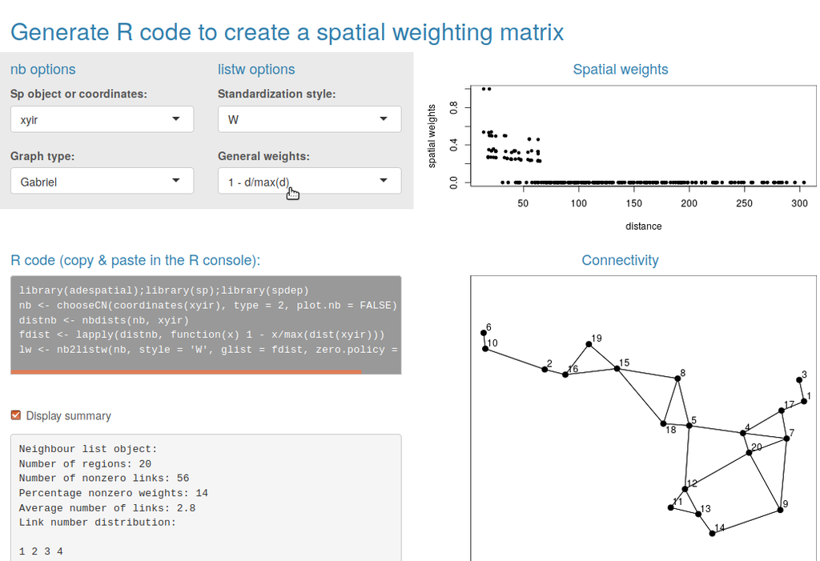

Figure 2: The interactive interface provided by the function `listw.explore`.

# 4 Creating spatial predictors

The package `adespatial` provide different tools to build spatial predictors that can be incorporated in multivariate analysis. They are orthogonal vectors stored in a object of class `orthobasisSp`. Orthogonal polynomials of geographic coordinates can be computed by the function `orthobasis.poly` whereas principal coordinates of neighbour matrices (PCNM, Borcard and Legendre (2002)) are obtained by the function `dbmem`.

The Moran’s Eigenvectors Maps (MEMs) provide the most flexible framework. If we consider the $n \times n$ spatial weighting matrix $\mathbf{W} = [w_{ij}]$, they are the $n-1$ eigenvectors obtained by the diagonalization of the doubly-centred SWM:

$$\mathbf{\Omega V}= \mathbf{V \Lambda}$$

where $\mathbf{\Omega} = \mathbf{HWH}$ is the doubly-centred SWM and $\mathbf{H} = \left ( \mathbf{I}-\mathbf{11}\hspace{-0.05cm}^{\top}\hspace{-0.05cm}/n \right )$ is the centring operator.

MEMs are orthogonal vectors with a unit norm that maximize Moran’s coefficient of spatial autocorrelation (Griffith 1996; Dray et al. 2012) and are stored in matrix $\mathbf{V}$.

MEMs are provided by the functions `scores.listw` or `mem` of the `adespatial` package. These two functions are exactly identical (both are kept for historical reasons and compatibility) and return an object of class `orthobasisSp`.

```r
mem.gab <- mem(listwgab)
mem.gab
```

```
## Orthobasis with 97 rows and 96 columns
## Only 6 rows and 4 columns are shown
##        MEM1     MEM2       MEM3        MEM4
## 1 0.9251530 2.050270 -0.6159371 -1.13648688
## 2 0.8495416 1.859746 -0.4163876 -0.57971608
## 3 0.8092292 1.699300 -0.1970169  0.02251458
## 4 1.0455937 2.177654 -0.7488499 -1.45727142
## 5 0.7098875 1.571499 -0.5144638 -1.00604362
## 6 0.9629486 2.017900 -0.5572747 -0.92335694
```

This object contains MEMs, stored as a `data.frame` and other attributes:

```r
class(mem.gab)
```

```
## [1] "orthobasisSp" "orthobasis"   "data.frame"
```

```r
names(attributes(mem.gab))
```

```
## [1] "names"     "class"     "row.names" "values"    "weights"   "call"
```

The eigenvalues associated to MEMs are stored in the attribute called `values`:

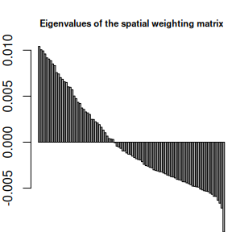

```r
    barplot(attr(mem.gab, "values"),
        main = "Eigenvalues of the spatial weighting matrix", cex.main = 0.7)
```

```r
par(oldpar)
```

A `plot` method is provided to represent MEMs. By default, eigenvectors are represented as a table (sites as rows, MEMs as columns). This representation is usually not informative and it is better to map MEMs in the geographical space by documenting the argument `SpORcoords`:

```r
plot(mem.gab[,c(1, 5, 10, 20, 30, 40, 50, 60, 70)], SpORcoords = mxy)
```

[output not shown]

or using the more flexible `s.value` function:

[figure not shown]

```r
s.value(mxy, mem.gab[,c(1, 5, 10, 20, 30, 40, 50, 60, 70)], symbol = "circle", ppoint.cex = 0.6)
```

Moran’s I can be computed and tested for each eigenvector with the `moran.randtest` function:

```r
moranI <- moran.randtest(mem.gab, listwgab, 99)
```

As demonstrated in Dray et al. (2006), eigenvalues and Moran’s I are equal (post-multiply by a constant):

```r
head(attr(mem.gab, "values") / moranI$obs)
```

```
## MEM1.statistic MEM2.statistic MEM3.statistic MEM4.statistic MEM5.statistic
##     0.01030928     0.01030928     0.01030928     0.01030928     0.01030928
## MEM6.statistic
##     0.01030928
```

# 5 Describing spatial patterns

In the previous sections, we considered only the spatial information as a geographic map, a spatial weighting matrix (SWM) or a basis of spatial predictors (e.g., MEM). In the next sections, we will show how the spatial information can be integrated to analyze multivariate data and identify multiscale spatial patterns. The dataset `mafragh` available in `ade4` will be used to illustrate the different methods.

## 5.1 Moran’s coefficient of spatial autocorrelation

The SWM can be used to compute the level of spatial autocorrelation of a quantitative variable using the Moran’s coefficient. If we consider the $n \times 1$ vector $\mathbf{x} = \left ( {x_1 \cdots x_n } \right )\hspace{-0.05cm}^{\top}\hspace{-0.05cm}$ containing measurements of a quantitative variable for $n$ sites and $\mathbf{W} = [w_{ij}]$ the SWM. The usual formulation for Moran’s coefficient (MC) of spatial autocorrelation is:
$$MC(\mathbf{x}) = \frac{n\sum\nolimits_{\left( 2 \right)} {w_{ij} (x_i
-\bar
{x})(x_j -\bar {x})} }{\sum\nolimits_{\left( 2 \right)} {w_{ij} }
\sum\nolimits_{i = 1}^n {(x_i -\bar {x})^2} }\mbox{ where
}\sum\nolimits_{\left( 2 \right)} =\sum\limits_{i = 1}^n {\sum\limits_{j
= 1}^n
} \mbox{ with }i\ne j$$

MC can be rewritten using matrix notation:
$$MC(\mathbf{x}) =
\frac{n}{\mathbf{1}\hspace{-0.05cm}^{\top}\hspace{-0.05cm}\mathbf{W1}}\frac{\mathbf{z}\hspace{-0.05cm}^{\top}\hspace{-0.05cm}{\mathbf{Wz}}}{\mathbf{z}\hspace{-0.05cm}^{\top}\hspace{-0.05cm}\mathbf{z}}$$
where $\mathbf{z} = \left ( \mathbf{I}-\mathbf{1}\mathbf{1}\hspace{-0.05cm}^{\top}\hspace{-0.05cm}/n \right )\mathbf{x}$ is the vector of centred values (i.e., $z_i = x_i-\bar{x}$).

The function `moran.mc` of the `spdep` package allows to compute and test, by permutation, the significance of the Moran’s coefficient. A wrapper is provided by the `moran.randtest` function to test simultaneously and independently the spatial structure for several variables.

[figure not shown]

```r
sp.env <- SpatialPolygonsDataFrame(Sr = mafragh$Spatial, data = mafragh$env, match.ID = FALSE)
maps.env <- s.Spatial(sp.env, col = fpalette(6), nclass = 6)
```

```r
MC.env <- moran.randtest(mafragh$env, listwgab, nrepet = 999)
MC.env
```

```
## class: krandtest lightkrandtest
## Monte-Carlo tests
## Call: moran.randtest(x = mafragh$env, listw = listwgab, nrepet = 999)
##
## Number of tests:   11
##
## Adjustment method for multiple comparisons:   none
## Permutation number:   999
##            Test       Obs   Std.Obs   Alter Pvalue
## 1          Clay 0.4464655  6.552261 greater  0.001
## 2          Silt 0.3967605  5.946167 greater  0.001
## 3          Sand 0.1218959  2.114549 greater  0.033
## 4           K2O 0.2916865  4.470113 greater  0.001
## 5          Mg++ 0.2040580  3.220200 greater  0.003
## 6      Na+/100g 0.3404142  5.138034 greater  0.001
## 7            K+ 0.6696787 10.193028 greater  0.001
## 8  Conductivity 0.3843430  5.891744 greater  0.001
## 9     Retention 0.2217547  3.609803 greater  0.003
## 10        Na+/l 0.3075238  4.791118 greater  0.001
## 11    Elevation 0.6136770  9.047577 greater  0.001
```

For a given SWM, the upper and lower bounds of MC are equal to $\lambda_{max} (n/\mathbf{1}\hspace{-0.05cm}^{\top}\hspace{-0.05cm}\mathbf{W1})$ and $\lambda_{min} (n/\mathbf{1}\hspace{-0.05cm}^{\top}\hspace{-0.05cm}\mathbf{W1})$ where $\lambda_{max}$ and $\lambda_{min}$ are the extreme eigenvalues of $\mathbf{\Omega}$. These extreme values are returned by the `moran.bounds` function:

```r
mc.bounds <- moran.bounds(listwgab)
mc.bounds
```

```
##       Imin       Imax
## -0.9474872  1.0098330
```

Hence, it is possible to display Moran’s coefficients computed on environmental variables and the minimum and maximum values for the given SWM:

[figure not shown]

```r
env.maps <- s1d.barchart(MC.env$obs, labels = MC.env$names, plot = FALSE, xlim = 1.1 * mc.bounds, paxes.draw = TRUE, pgrid.draw = FALSE)
addline(env.maps, v = mc.bounds, plot = TRUE, pline.col = 'red', pline.lty = 3)
```

## 5.2 Decomposing Moran’s coefficient

The standard test based on MC is not able to detect the coexistence of positive and negative autocorrelation structures (i.e., it leads to a non-significant test). The `moranNP.randtest` function allows to decompose the standard MC statistic into two additive parts and thus to test for positive and negative autocorrelation separately (Dray 2011). For instance, we can test the spatial distribution of Magnesium. Only positive autocorrelation is detected:

```r
NP.Mg <- moranNP.randtest(mafragh$env[,5], listwgab, nrepet = 999, alter = "two-sided")
NP.Mg
```

```
## class: krandtest lightkrandtest
## Monte-Carlo tests
## Call: moranNP.randtest(x = mafragh$env[, 5], listw = listwgab, nrepet = 999,
##     alter = "two-sided")
##
## Number of tests:   2
##
## Adjustment method for multiple comparisons:   none
## Permutation number:   999
##   Test        Obs  Std.Obs   Alter Pvalue
## 1   I+  0.3611756 3.743501 greater  0.002
## 2   I- -0.1571176 1.552759    less  0.944
```

[figure not shown]

```r
plot(NP.Mg)
```

```r
sum(NP.Mg$obs)
```

```
## [1] 0.204058
```

```r
MC.env$obs[5]
```

```
## Mg++.statistic
##       0.204058
```

## 5.3 MULTISPATI analysis

When multivariate data are considered, it is possible to search for spatial structures by computing univariate statistics (e.g., Moran’s Coefficient) on each variable separately. Another alternative is to summarize data by multivariate methods and then detect spatial structures using the output of the analysis. For instance, we applied a centred principal component analysis on the abundance data:

```r
pca.hell <- dudi.pca(mafragh$flo, scale = FALSE, scannf = FALSE, nf = 2)
```

MC can be computed for PCA scores and the associated spatial structures can be visualized on a map:

```r
moran.randtest(pca.hell$li, listw = listwgab)
```

```
## class: krandtest lightkrandtest
## Monte-Carlo tests
## Call: moran.randtest(x = pca.hell$li, listw = listwgab)
##
## Number of tests:   2
##
## Adjustment method for multiple comparisons:   none
## Permutation number:   999
##    Test       Obs  Std.Obs   Alter Pvalue
## 1 Axis1 0.4830837 7.405295 greater  0.001
## 2 Axis2 0.4613738 7.119489 greater  0.001
```

[figure not shown]

```r
s.value(mxy, pca.hell$li, Sp = mafragh$Spatial.contour, symbol = "circle", col = c("white", "palegreen4"), ppoint.cex = 0.6)
```

PCA results are highly spatially structured. Results can be optimized, compared to this two-step procedure, by searching directly for multivariate spatial structures. The `multispati` function implements a method (Dray et al. 2008) that search for axes maximizing the product of variance (multivariate aspect) by MC (spatial aspect):

```r
ms.hell <- multispati(pca.hell, listw = listwgab, scannf = F)
```

The `summary` method can be applied on the resulting object to compare the results of initial analysis (axis 1 (RS1) and axis 2 (RS2)) and those of the multispati method (CS1 and CS2):

```r
summary(ms.hell)
```

```
##
## Multivariate Spatial Analysis
## Call: multispati(dudi = pca.hell, listw = listwgab, scannf = F)
##
## Scores from the initial duality diagram:
##          var      cum     ratio     moran
## RS1 5.331174 5.331174 0.2834660 0.4830837
## RS2 1.972986 7.304159 0.3883725 0.4613738
##
## Multispati eigenvalues decomposition:
##          eig      var     moran
## CS1 2.933824 4.833900 0.6069269
## CS2 1.210573 1.892671 0.6396110
```

The MULTISPATI analysis allows to better identify spatial structures (higher MC values).

Scores of the analysis can be mapped and highlight some spatial patterns of community composition:

[figure not shown]

```r
g.ms.maps <- s.value(mafragh$xy, ms.hell$li, Sp = mafragh$Spatial.contour, symbol = "circle", col = c("white", "palegreen4"), ppoint.cex = 0.6)
```

The spatial distribution of several species can be inserted to facilitate the interpretation of the outputs of the analysis:

[figure not shown]

```r
g.ms.spe <- s.arrow(ms.hell$c1, plot = FALSE)
g.abund <- s.value(mxy, mafragh$flo[, c(12,11,31,16)],
    Sp = mafragh$Spatial.contour, symbol = "circle", col = c("black", "palegreen4"), plegend.drawKey = FALSE, ppoint.cex = 0.4, plot = FALSE)
p1 <- list(c(0.05, 0.65), c(0.01, 0.25), c(0.74, 0.58), c(0.55, 0.05))
for (i in 1:4)
g.ms.spe <- insert(g.abund[[i]], g.ms.spe, posi = p1[[i]], ratio = 0.25, plot = FALSE)
g.ms.spe
```

# 6 Multiscale analysis with MEM

All the methods presented in the previous section consider the whole SWM to integrate the spatial information. In this section, we present alternatives that use MEM to introduce the notion of space at multiple scales.

## 6.1 Scalogram and MSPA

The full set of MEMs provide a basis of orthogonal vectors that can be used to decompose the total variance of a given variable at multiple scales. This approach consists simply in computing $R^2$ values associated to each MEM to build a scalogram indicating the part of variance explained by each MEM. These values can be tested by a permutation procedure. Here, we illustrate the procedure with the abundance of *Bolboschoenus maritimus* (Sp11) which is mainly located in the central part of the study area:

[figure not shown]

```r
scalo <- scalogram(mafragh$flo[,11], mem.gab)
plot(scalo)
```

As the number of MEMs is equal to the number of sites minus one and as MEMs are othogonal, the variance is fully decomposed:

```r
sum(scalo$obs)
```

```
## [1] 1
```

When the number of MEMs is high, the results provided by this approach can be difficult to interpret. In this case it can be advantageous to use smoothed scalograms (using the `nblocks` argument) where spatial components are formed by groups of successive MEMs:

[figure not shown]

```r
plot(scalogram(mafragh$flo[,11], mem(listwgab), nblocks = 20))
```

It is possible to compute scalograms for all the species of the data table. These scalograms can be stored in a table and analysing this table with a PCA allows to identify the important scales of the data set and the similarities between species based on their spatial distributions (Jombart et al. 2009). This analysis named Multiscale Patterns Analysis (MSPA) is available in the `mspa` function that takes the results of a multivariate analysis (an object of class `dudi`) as argument:

[figure not shown]

```r
mspa.hell <- mspa(pca.hell, listwgab, scannf = FALSE, nf = 2)

g.mspa <- scatter(mspa.hell, posieig = "topright", plot = FALSE)
g.mem <- s.value(mafragh$xy, mem.gab[, c(1, 2, 6, 3)], Sp = mafragh$Spatial.contour, ppoints.cex = 0.4, plegend.drawKey = FALSE, plot = FALSE)
g.abund <- s.value(mafragh$xy, mafragh$flo[, c(31,54,25)], Sp = mafragh$Spatial.contour, symbol = "circle", col = c("black", "palegreen4"), plegend.drawKey = FALSE, ppoint.cex = 0.4, plot = FALSE)

p1 <- list(c(0.01, 0.44), c(0.64, 0.15), c(0.35, 0.01), c(0.15, 0.78))
for (i in 1:4)
g.mspa <- insert(g.mem[[i]], g.mspa, posi = p1[[i]], plot = FALSE)

p2 <- list(c(0.27, 0.54), c(0.35, 0.35), c(0.75, 0.31))
for (i in 1:3)
g.mspa <- insert(g.abund[[i]], g.mspa, posi = p2[[i]], plot = FALSE)

g.mspa
```

## 6.2 Selection of SWM and MEM

Scalograms and MSPA require the full set of MEMs to decompose the total variation. However, regression-based methods (described in next sections) could suffer from overfitting if the number of explanatory variables is too high and thus require a procedure to reduce the number of MEMs. The function `mem.select` proposes different alternatives to perform this selection using the argument `method` (Bauman, Drouet, Dray, et al. 2018). By default, only MEMs associated to positive eigenvalues are considered (argument `MEM.autocor = "positive"`) and a forward selection (based on $R^2$ statistic) is performed after a global test (`method = "FWD"`):

```r
mem.gab.sel <- mem.select(pca.hell$tab, listw = listwgab)
```

```
## Procedure stopped (alpha criteria): pvalue for variable 16 is 0.075000 (> 0.050000)
```

```r
mem.gab.sel$global.test
```

```
## $obs
## [1] 0.3593333
##
## $pvalue
## [1] 1e-04
```

```r
mem.gab.sel$summary
```

```
##    variables order         R2      R2Cum   AdjR2Cum pvalue
## 1       MEM1     1 0.08696619 0.08696619 0.07735531  0.001
## 2       MEM2     2 0.05675316 0.14371935 0.12550061  0.001
## 3       MEM6     6 0.04244014 0.18615948 0.15990656  0.001
## 4       MEM4     4 0.03528604 0.22144553 0.18759533  0.001
## 5       MEM5     5 0.02987158 0.25131711 0.21018069  0.002
## 6      MEM12    12 0.02553209 0.27684919 0.22863914  0.001
## 7       MEM3     3 0.02515410 0.30200330 0.24710468  0.002
## 8       MEM7     7 0.01870460 0.32070790 0.25895407  0.010
## 9      MEM10    10 0.01810649 0.33881440 0.27041589  0.012
## 10     MEM17    17 0.01801775 0.35683215 0.28204519  0.019
## 11     MEM31    31 0.01549756 0.37232971 0.29110179  0.016
## 12      MEM9     9 0.01472660 0.38705632 0.29949293  0.024
## 13     MEM11    11 0.01390862 0.40096493 0.30714016  0.036
## 14     MEM35    35 0.01279786 0.41376280 0.31367352  0.045
## 15     MEM16    16 0.01217328 0.42593608 0.31962795  0.040
```

Results of the global test and of the forward selection are returned in elements `global.test` and `summary`. The subset of selected MEMs are in `MEM.select` and can be used in subsequent analysis (see sections on Redundancy Analysis and Variation Partitioning).

```r
class(mem.gab.sel$MEM.select)
```

```
## [1] "orthobasisSp" "orthobasis"   "data.frame"
```

```r
dim(mem.gab.sel$MEM.select)
```

```
## [1] 97 15
```

Different SWMs can be defined for a given data set. An important issue concerns the selection of a SWM. This choice can be driven by biological hypotheses but a data-driven procedure is provided by the `listw.select` function. A list of potential candidates can be built using the `listw.candidates` function. Here, we create four candidates using two definitions for neighborhood (Gabriel and Relative graphs using `c("gab", "rel")`) and two weighting functions (binary and linear using `c("bin", "flin")`):

```r
cand.lw <- listw.candidates(mxy, nb = c("gab", "rel"), weights = c("bin", "flin"))
```

The function `listw.select` proposes different methods for selecting a SWM (Bauman, Drouet, Fortin, et al. 2018). The procedure is very similar to the one proposed by `mem.select` except that p-value corrections are applied on global tests taking into account the fact that several candidates are used. By default (`method = "FWD"`), it applies forward selection on the significant SWMs and selects among these the SWM for which the subset of MEMs yields the highest adjusted R.

```r
sel.lw <- listw.select(pca.hell$tab, candidates = cand.lw, nperm = 99)
```

```
## Procedure stopped (alpha criteria): pvalue for variable 16 is 0.080000 (> 0.050000)
## Procedure stopped (alpha criteria): pvalue for variable 15 is 0.060000 (> 0.050000)
## Procedure stopped (alpha criteria): pvalue for variable 19 is 0.070000 (> 0.050000)
## Procedure stopped (alpha criteria): pvalue for variable 20 is 0.100000 (> 0.050000)
```

A summary of the procedure is available:

```r
sel.lw$candidates
```

```
##                     R2Adj     Pvalue N.var R2Adj.select
## Gabriel_Binary  0.3571605 0.00039994    15    0.2938182
## Gabriel_Linear  0.3745815 0.00039994    14    0.3059982
## Relative_Binary 0.3788734 0.00039994    18    0.3299666
## Relative_Linear 0.3728263 0.00039994    19    0.3349199
```

```r
sel.lw$best.id
```

```
## Relative_Linear
##               4
```

The corresponding SWM can be obtained by

```r
lw.best <- cand.lw[[sel.lw$best.id]]
```

The subset of MEMs corresponding to the best SWM is also returned by the function:

```r
sel.lw$best
```

```
## $global.test
## $global.test$obs
## [1] 0.3728263
##
## $global.test$pvalue
## [1] 0.00039994
##
##
## $MEM.select
## Orthobasis with 97 rows and 19 columns
## Only 6 rows and 4 columns are shown
##          MEM8     MEM2       MEM7       MEM3
## 1  0.57335813 2.041032 -0.3239282 -0.2075280
## 2  0.84824433 1.753831  0.9633804 -0.1781151
## 3  0.58158368 1.020786  1.1627724 -0.1024424
## 4 -0.68418987 1.297336 -2.5394961 -0.1218499
## 5 -0.03242453 1.254399 -1.1615363 -0.1271501
## 6  0.49026241 2.343757 -0.3132711 -0.2287866
##
## $summary
##    variables order         R2     R2Cum   AdjR2Cum pvalue
## 1       MEM8     8 0.05804130 0.0580413 0.04812594   0.01
## 2       MEM2     2 0.04694559 0.1049869 0.08594406   0.01
## 3       MEM7     7 0.04184439 0.1468313 0.11930971   0.01
## 4       MEM3     3 0.03648604 0.1833173 0.14780937   0.01
## 5      MEM38    38 0.03294060 0.2162579 0.17319516   0.01
## 6       MEM1     1 0.02556350 0.2418214 0.19127617   0.01
## 7      MEM11    11 0.02461285 0.2664343 0.20873808   0.01
## 8      MEM22    22 0.02301480 0.2894491 0.22485352   0.01
## 9       MEM9     9 0.01962969 0.3090788 0.23760414   0.01
## 10     MEM13    13 0.01827667 0.3273554 0.24914093   0.02
## 11      MEM6     6 0.01795449 0.3453099 0.26058531   0.01
## 12     MEM12    12 0.01699980 0.3623097 0.27121110   0.01
## 13     MEM16    16 0.01698129 0.3792910 0.28207151   0.03
## 14     MEM37    37 0.01683864 0.3961296 0.29302982   0.02
## 15     MEM14    14 0.01669087 0.4128205 0.30408356   0.02
## 16     MEM21    21 0.01363371 0.4264542 0.31174506   0.03
## 17     MEM27    27 0.01355500 0.4400092 0.31950487   0.02
## 18     MEM17    17 0.01343125 0.4534405 0.32731134   0.02
## 19      MEM5     5 0.01310988 0.4665504 0.33491992   0.04
```

## 6.3 Canonical Analysis

Canonical methods are widely used to explain the structure of an abundance table by environmental and/or spatial variables. For instance, Redundancy Analysis (RDA) is available in functions `pcaiv` (package `ade4`) or `rda` (package `vegan`). RDA can be applied using selected MEMs as explanatory variables to study the spatial patterns in plant communities, :

```r
rda.hell <- pcaiv(pca.hell, sel.lw$best$MEM.select, scannf = FALSE)
```

The permutation test based on the percentage of variation explained by the spatial predictors ($R^2$) is highly significant:

```r
test.rda <- randtest(rda.hell)
test.rda
```

```
## Monte-Carlo test
## Call: randtest.pcaiv(xtest = rda.hell)
##
## Observation: 0.4665504
##
## Based on 99 replicates
## Simulated p-value: 0.01
## Alternative hypothesis: greater
##
##      Std.Obs  Expectation     Variance
## 15.485157208  0.195439797  0.000306522
```

[figure not shown]

```r
plot(test.rda)
```

Associated spatial structures can be mapped:

[figure not shown]

```r
s.value(mxy, rda.hell$li, Sp = mafragh$Spatial.contour, symbol = "circle", col = c("white", "palegreen4"), ppoint.cex = 0.6)
```

## 6.4 Variation partitioning

Spatial structures identified by Redundancy Analysis in the previous section can be due to niche filtering or other processes (e.g., neutral dynamics). Variation partitioning (Borcard et al. 1992) based on adjusted $R^2$ (Peres-Neto et al. 2006) can be used to identify the part of spatial structures that can be explained or not by environmental predictors. This method is implemented in the function `varpart` of package `vegan` that is able to deal with up to four tables of predictors:

```r
library(vegan)
vp1 <- varpart(pca.hell$tab, mafragh$env, sel.lw$best$MEM.select)
vp1
```

```
##
## Partition of variance in RDA
##
## Call: varpart(Y = pca.hell$tab, X = mafragh$env,
## sel.lw$best$MEM.select)
##
## Explanatory tables:
## X1:  mafragh$env
## X2:  sel.lw$best$MEM.select
##
## No. of explanatory tables: 2
## Total variation (SS): 1824.3
##             Variance: 19.003
## No. of observations: 97
##
## Partition table:
##                      Df R.squared Adj.R.squared Testable
## [a+c] = X1           11   0.23666       0.13787     TRUE
## [b+c] = X2           19   0.46655       0.33492     TRUE
## [a+b+c] = X1+X2      30   0.55492       0.35260     TRUE
## Individual fractions
## [a] = X1|X2          11                 0.01768     TRUE
## [b] = X2|X1          19                 0.21473     TRUE
## [c]                   0                 0.12019    FALSE
## [d] = Residuals                         0.64740    FALSE
## ---
## Use function 'rda' to test significance of fractions of interest
```

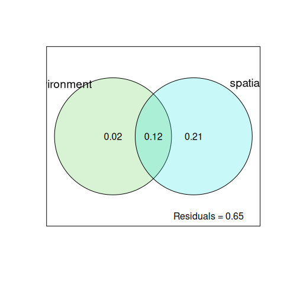

```r
plot(vp1, bg = c(3, 5), Xnames = c("environment", "spatial"))
```

A simpler function `varipart` is available in `ade4` that is able to deal only with two tables of explanatory variables:

```r
vp2 <- varipart(pca.hell$tab, mafragh$env, sel.lw$best$MEM.select)
vp2
```

[output not shown]

Estimates and testing procedures associated to standard variation partitioning can be biased in the presence of spatial autocorrelation in both response and explanatory variables. To solve this issue, `adespatial` provides functions to perform spatially-constrained randomization using Moran’s Spectral Randomization.

## 6.5 Testing with Moran’s Spectral Randomization

Moran’s Spectral Randomization (MSR) allows to generate random replicates that preserve the spatial structure of the original data (Wagner and Dray 2015). These replicates can be used to create spatially-constrained null distribution. For instance, we consider the case of bivariate correlation between Elevation and Sodium:

```r
cor(mafragh$env[,10], mafragh$env[,11])
```

```
## [1] -0.4033508
```

This correlation can be tested by a standard t-test:

```r
cor.test(mafragh$env[,10], mafragh$env[,11])
```

```
##
##  Pearson's product-moment correlation
##
## data:  mafragh$env[, 10] and mafragh$env[, 11]
## t = -4.2964, df = 95, p-value = 4.195e-05
## alternative hypothesis: true correlation is not equal to 0
## 95 percent confidence interval:
##  -0.5579139 -0.2217439
## sample estimates:
##        cor
## -0.4033508
```

However this test assumes independence between observations. This condition is not observed in our data as suggested by the computation of MC:

```r
moran.randtest(mafragh$env[,10], lw.best)
```

```
## Monte-Carlo test
## Call: moran.randtest(x = mafragh$env[, 10], listw = lw.best)
##
## Observation: 0.3833853
##
## Based on 999 replicates
## Simulated p-value: 0.001
## Alternative hypothesis: greater
##
## Std.Obs.statistic       Expectation          Variance
##       4.341745200      -0.007295609       0.008096842
```

An alternative is to generate random replicates for the two variables with same level of spatial autocorrelation:

```r
msr1 <- msr(mafragh$env[,10], lw.best)
summary(moran.randtest(msr1, lw.best, nrepet = 2)$obs)
```

```
##    Min. 1st Qu.  Median    Mean 3rd Qu.    Max.
##  0.3682  0.3775  0.3818  0.3818  0.3863  0.3940
```

```r
msr2 <- msr(mafragh$env[,11], lw.best)
```

Then, the statistic is computed on observed and simulated data to build a randomization test:

```r
obs <- cor(mafragh$env[,10], mafragh$env[,11])
sim <- sapply(1:ncol(msr1), function(i) cor(msr1[,i], msr2[,i]))
testmsr <- as.randtest(obs = obs, sim = sim, alter = "two-sided")
testmsr
```

```
## Monte-Carlo test
## Call: as.randtest(sim = sim, obs = obs, alter = "two-sided")
##
## Observation: -0.4033508
##
## Based on 99 replicates
## Simulated p-value: 0.01
## Alternative hypothesis: two-sided
##
##      Std.Obs  Expectation     Variance
## -2.595649598 -0.002805914  0.023812783
```

The function `msr` is generic and several methods are implemented in `adespatial`. For instance, it can be used to correct estimates and significance of the environmental fraction in the case of a variation partitioning (Clappe et al. 2018) computed with the `varipart` function:

```r
msr(vp2, listwORorthobasis = lw.best)
```

```
## Variation Partitioning
## class: varipart list
##
## Test of fractions:
## Monte-Carlo test
## Call: msr.varipart(x = vp2, listwORorthobasis = lw.best)
##
## Observation: 0.2366554
##
## Based on 999 replicates
## Simulated p-value: 0.001
## Alternative hypothesis: greater
##
##      Std.Obs  Expectation     Variance
## 3.9034647182 0.1530324427 0.0004589342
##
## Individual fractions:
##         a         b         c         d
## 0.0883648 0.1482906 0.3182598 0.4450848
##
## Adjusted fractions:
##          a          b          c          d
## 0.01073779 0.08799438 0.24642153 0.65484630
```

# References

Bauman, D, T Drouet, S Dray, and J Vleminckx. 2018. “Disentangling good from bad practices in the selection of spatial or phylogenetic eigenvectors.” *Ecography* 41: 1638–49.

Bauman, D, T Drouet, M J Fortin, and S Dray. 2018. “Optimizing the choice of a spatial weighting matrix in eigenvector-based methods.” *Ecology* 99 (10): 2159–66.

Borcard, D, and P Legendre. 2002. “All-scale spatial analysis of ecological data by means of principal coordinates of neighbour matrices.” *Ecological Modelling* 153: 51–68.

Borcard, D, P Legendre, and P Drapeau. 1992. “Partialling out the spatial component of ecological variation.” *Ecology* 73 (3): 1045–55.

Clappe, S, S Dray, and P R Peres-Neto. 2018. “Beyond neutrality: disentangling the effects of species sorting and spurious correlations in community analysis.” *Ecology* 99 (8): 1737–47.

Dray, S. 2011. “A new perspective about Moran’s coefficient: spatial autocorrelation as a linear regression problem.” *Geographical Analysis* 43: 127–41.

Dray, S, and A B Dufour. 2007. “The ade4 package: implementing the duality diagram for ecologists.” *Journal of Statistical Software* 22 (4): 1–20.

Dray, S, P Legendre, and P R Peres-Neto. 2006. “Spatial modeling: a comprehensive framework for principal coordinate analysis of neighbor matrices (PCNM).” *Ecological Modelling* 196: 483–93.

Dray, S, R Pélissier, P Couteron, et al. 2012. “Community ecology in the age of multivariate multiscale spatial analysis.” *Ecological Monographs* 82 (3): 257–75.

Dray, S, S Saïd, and F Débias. 2008. “Spatial ordination of vegetation data using a generalization of Wartenberg’s multivariate spatial correlation.” *Journal of Vegetation Science* 19: 45–56.

Griffith, D A. 1996. “Spatial autocorrelation and eigenfunctions of the geographic weights matrix accompanying geo-referenced data.” *Canadian Geographer* 40 (4): 351–67.

Jombart, T, S Dray, and A B Dufour. 2009. “Finding essential scales of spatial variation in ecological data: a multivariate approach.” *Ecography* 32: 161–68.

Peres-Neto, P R, P Legendre, S Dray, and D Borcard. 2006. “Variation partitioning of species data matrices: estimation and comparison of fractions.” *Ecology* 87: 2614–25.

Siberchicot, A, A Julien-Laferrière, A B Dufour, J Thioulouse, and S Dray. 2017. “adegraphics: An S4 lattice-based package for the representation of multivariate data.” *R Journal* 9 (2).

Wagner, H H, and S Dray. 2015. “Generating spatially constrained null models for irregularly spaced data using Moran spectral randomization methods.” *Methods in Ecology and Evolution* 6 (10): 1169–78.